# Ejercicio 2: Potabilidad del agua

## 3. PARTICIÓN ENTRENAMIENTO / PRUEBA (ESTRATIFICADA)

Reservamos 25% de las muestras para prueba y entrenamos con el 75% restante. Estratificamos por potable para que la mezcla de clases sea la misma en ambas particiones. La prueba no se vuelve a tocar hasta el final.

```r
set.seed(2026)
agua_split <- initial_split(data = agua,
                            prop = 0.75,
                            strata = potable)
```

```r
agua_entrenamiento <- agua_split %>% training()
agua_prueba        <- agua_split %>% testing()
```

```r
# Confirmamos que las proporciones se mantuvieron tras estratificar.
table(agua_entrenamiento$potable) %>% prop.table()
```

```
       no        si
0.5853659 0.4146341
```

```r
table(agua_prueba$potable) %>% prop.table()
```

```
       no        si
0.5853659 0.4146341
```

## 4. RECETA DE FEATURE ENGINEERING

Igual que siempre, el orden de los pasos no es opcional. Se imputa primero porque los pasos que siguen no aceptan NAs; después se limpia, se filtra colinealidad y se normaliza.

1. step_impute_median: tapa los faltantes de ph y sulfatos_mg_l con la mediana de cada variable (robusta a valores atípicos).
2. step_nzv: quita predictores con varianza casi nula (sin poder discriminante).
3. step_corr: descarta uno de los predictores muy correlacionados (umbral 0.7); aquí debería eliminar conductividad o sólidos disueltos.
4. step_normalize: estandariza todos los predictores a media 0 y desviación 1. EN ESTE EJERCICIO ES EL PASO DECISIVO: sin normalizar, solidos_disueltos_ppm (en miles) y conductividad (en cientos) dominarían el cálculo de distancia y el pH o la turbidez (de un solo dígito) prácticamente no contarían. Normalizar pone a todas las variables en igualdad de condiciones.

Como todos los predictores son numéricos, no hace falta step_unknown ni step_dummy (no hay categóricas). Añadimos step_zv() como salvaguarda por si algún predictor quedara constante tras los pasos previos.

```r
receta_agua <- recipe(potable ~ ., data = agua_entrenamiento) %>%
  step_impute_median(all_numeric_predictors()) %>%
  step_nzv(all_predictors()) %>%
  step_corr(all_numeric_predictors(), threshold = 0.7) %>%
  step_normalize(all_numeric_predictors()) %>%
  step_zv(all_predictors())
```

```r
# Inspección opcional: vemos el resultado del preprocesamiento. Nótese que
# tras step_normalize todas las columnas quedan en la misma escala.
receta_agua %>%
  prep(training = agua_entrenamiento) %>%
  bake(new_data = NULL) %>%
  glimpse()
```

```
Rows: 615
Columns: 9
$ ph                   <dbl> -1.0529594, 0.7134422, -0.6420007, 0.1510776, 0.6…
$ dureza_mg_l          <dbl> -0.15288719, 0.74511717, -0.31117948, -0.94130458…
$ cloraminas_ppm       <dbl> 1.745294527, -0.120903322, 2.056327501, -1.974659…
$ sulfatos_mg_l        <dbl> -0.47834080, -1.07958864, 1.20372161, -1.19888385…
$ conductividad_us_cm  <dbl> 0.040909321, -1.158963245, 0.346234037, 0.0819763…
$ carbono_organico_ppm <dbl> -0.3584871, 1.0035912, 1.5772592, 0.8103233, -1.3…
$ trihalometanos_ug_l  <dbl> -2.02229195, 2.10730639, -0.15240007, 1.09013394,…
$ turbidez_ntu         <dbl> -0.2187150, 0.1338662, 0.3227489, 0.7005145, -1.1…
$ potable              <fct> no, no, no, no, no, no, no, no, no, no, no, no, n…
```

## 5. WORKFLOW + MODELO KNN CON k FIJO (ARBITRARIO)

```r
#
# El workflow() une receta y modelo en un solo objeto. Al ajustarlo con
# fit(), corre prep+bake+fit por dentro; al predecir, aplica exactamente el
# mismo preprocesamiento a los datos nuevos. Esto evita el error clásico de
# olvidar transformar la base de prueba antes de predecir.
#
# Recordatorio de cómo funciona KNN: para clasificar una muestra de agua
# nueva, calcula su distancia a todas las muestras de entrenamiento, se queda
# con las k más cercanas y vota la clase mayoritaria entre ellas. No estima
# coeficientes: simplemente recuerda los datos (modelo "perezoso"). El número
# de vecinos k controla el equilibrio sesgo-varianza:
#   - k chico => frontera de decisión muy detallada, propensa a sobreajustar.
#   - k grande => frontera muy lisa, propensa a subajustar.
#
# Empezamos con k = 9 elegido arbitrariamente, solo como referencia.
#
# weight_func = "rectangular": KNN de VOTO MAYORITARIO no ponderado (los k
# vecinos pesan igual). Es la versión clásica y deja ver el equilibrio
# sesgo-varianza: con k muy grande la frontera se aplana y subajusta. El
# motor kknn por defecto pondera por distancia, lo que ocultaría ese efecto.
modelo_knn_fijo <- nearest_neighbor(neighbors = 9,
                                    weight_func = "rectangular") %>%
  set_engine("kknn") %>%
  set_mode("classification")
```

```r
workflow_knn_fijo <- workflow() %>%
  add_recipe(receta_agua) %>%
  add_model(modelo_knn_fijo)
```

```r
workflow_knn_fijo_fit <- workflow_knn_fijo %>%
  fit(data = agua_entrenamiento)
```

```r
# Predicción sobre la prueba (clase y probabilidades) usando el workflow.
predicciones_knn_fijo <- agua_prueba %>%
  select(potable) %>%
  bind_cols(predict(workflow_knn_fijo_fit, agua_prueba, type = "class")) %>%
  bind_cols(predict(workflow_knn_fijo_fit, agua_prueba, type = "prob"))
```

```r
# Métricas de referencia con k = 9.
metricas_clasificacion <- metric_set(accuracy, sensitivity, yardstick::spec)
metricas_clasificacion(predicciones_knn_fijo,
                       truth = potable,
                       estimate = .pred_class)
```

```
# A tibble: 3 × 3
  .metric     .estimator .estimate
  <chr>       <chr>          <dbl>
1 accuracy    binary         0.668
2 sensitivity binary         0.633
3 spec        binary         0.718
```

```r
roc_auc(predicciones_knn_fijo, truth = potable, .pred_no)
```

```
# A tibble: 1 × 3
  .metric .estimator .estimate
  <chr>   <chr>          <dbl>
1 roc_auc binary         0.752
```

## 6. TUNING DE k CON VALIDACIÓN CRUZADA

El k que usamos arriba fue una corazonada. k es un hiperparámetro: el modelo no lo aprende solo, lo decidimos nosotros antes de entrenar. Para elegirlo bien probamos varios valores y nos quedamos con el de mejor desempeño estimado, pero SIN mirar la base de prueba (si la usáramos para elegir, se contaminaría y dejaría de ser un examen limpio).

La herramienta es la validación cruzada sobre el entrenamiento. Un “fold” es una de las v porciones en que dividimos el entrenamiento. En cada iteración de la CV se aparta un fold como validación, se entrena con los v-1 restantes y se mide la métrica en el fold apartado; se rota hasta que cada fold haya sido validación una vez, y se promedian las v mediciones. Ese promedio (calculado para cada k candidato) es lo que comparamos.

```r
# 6.1 Modelo KNN con neighbors a determinar (tune()). Mantenemos
# weight_func = "rectangular" para que el tuning muestre un k intermedio
# óptimo y la caída del AUC cuando k crece demasiado.
modelo_knn_tune <- nearest_neighbor(neighbors = tune(),
                                    weight_func = "rectangular") %>%
  set_engine("kknn") %>%
  set_mode("classification")
```

```r
workflow_knn_tune <- workflow() %>%
  add_recipe(receta_agua) %>%
  add_model(modelo_knn_tune)
```

```r
# 6.2 Cinco folds estratificados por potable, sobre el entrenamiento. El
# set.seed hace reproducible la división en folds.
set.seed(2026)
folds_cv <- vfold_cv(data = agua_entrenamiento,
                     v = 5,
                     strata = potable)
```

```r
# 6.3 Grilla de candidatos de k. grid_regular() construye una cuadrícula
# uniforme dentro del rango indicado para neighbors(). Exploramos hasta k
# moderadamente grande para ver toda la curva sesgo-varianza y asegurarnos de
# que el óptimo no quede pegado al borde de la grilla.
grilla_k <- grid_regular(neighbors(range = c(1, 101)),
                         levels = 12)
```

```r
# 6.4 Conjunto de métricas a observar en el tuning. roc_auc es la guía
# principal porque no depende de un umbral de corte; el resto la matiza.
metricas_tuning <- metric_set(roc_auc, accuracy, sensitivity, yardstick::spec)
```

```r
# 6.5 Corremos el tuning: cada k se evalúa con la CV de 5 folds.
set.seed(2026)
resultados_tuning <- workflow_knn_tune %>%
  tune_grid(resamples = folds_cv,
            grid = grilla_k,
            metrics = metricas_tuning)
```

```r
# 6.6 Resultados promediados por k.
collect_metrics(resultados_tuning)
```

```
# A tibble: 48 × 7
   neighbors .metric     .estimator  mean     n std_err .config
       <int> <chr>       <chr>      <dbl> <int>   <dbl> <chr>
 1         1 accuracy    binary     0.631     5  0.0166 pre0_mod01_post0
 2         1 roc_auc     binary     0.633     5  0.0199 pre0_mod01_post0
 3         1 sensitivity binary     0.619     5  0.0235 pre0_mod01_post0
 4         1 spec        binary     0.647     5  0.0480 pre0_mod01_post0
 5        10 accuracy    binary     0.665     5  0.0130 pre0_mod02_post0
 6        10 roc_auc     binary     0.749     5  0.0205 pre0_mod02_post0
 7        10 sensitivity binary     0.622     5  0.0142 pre0_mod02_post0
 8        10 spec        binary     0.725     5  0.0164 pre0_mod02_post0
 9        19 accuracy    binary     0.663     5  0.0183 pre0_mod03_post0
10        19 roc_auc     binary     0.767     5  0.0165 pre0_mod03_post0
# ℹ 38 more rows
```

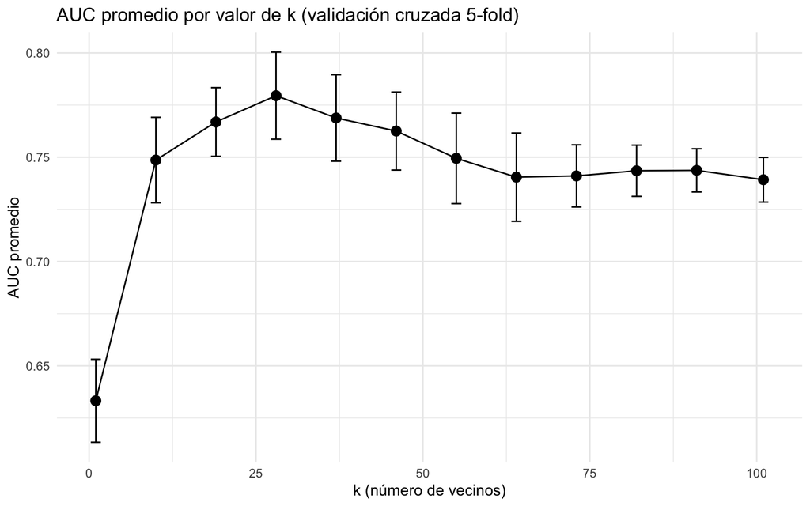

```r
# Gráfica AUC vs k. La leemos buscando dónde el AUC alcanza su máximo y se
# aplana: ese suele ser un buen k (ni tan chico que sobreajuste, ni tan
# grande que subajuste).
resultados_tuning %>%
  collect_metrics() %>%
  filter(.metric == "roc_auc") %>%
  ggplot(aes(x = neighbors, y = mean)) +
  geom_line() +
  geom_point(size = 3) +
  geom_errorbar(aes(ymin = mean - std_err, ymax = mean + std_err),
                width = 1.5) +
  labs(title = "AUC promedio por valor de k (validación cruzada 5-fold)",
       x = "k (número de vecinos)",
       y = "AUC promedio") +
  theme_minimal()
```

```r
# 6.7 Seleccionamos el k con mejor AUC promedio.
# Recordatorio: si el k ganador queda en el extremo de la grilla, conviene
# ampliar el rango y volver a tunear, porque podría haber un k mejor afuera.
mejor_k <- resultados_tuning %>% select_best(metric = "roc_auc")
mejor_k
```

```
# A tibble: 1 × 2
  neighbors .config
      <int> <chr>
1        28 pre0_mod04_post0
```

## 7. EVALUACIÓN FINAL CON last_fit()

finalize_workflow() fija el k ganador en el workflow. Después last_fit() hace, de un solo golpe, dos cosas: reentrena el modelo con ese k usando TODO el entrenamiento y lo evalúa sobre la prueba reservada. Es la estimación honesta del desempeño en datos que el modelo nunca vio.

```r
workflow_knn_final <- workflow_knn_tune %>%
  finalize_workflow(mejor_k)
```

```r
ajuste_final <- workflow_knn_final %>%
  last_fit(split = agua_split,
           metrics = metricas_tuning)
```

```r
# 7.1 Métricas finales sobre la prueba.
collect_metrics(ajuste_final)
```

```
# A tibble: 4 × 4
  .metric     .estimator .estimate .config
  <chr>       <chr>          <dbl> <chr>
1 accuracy    binary         0.717 pre0_mod0_post0
2 sensitivity binary         0.667 pre0_mod0_post0
3 spec        binary         0.788 pre0_mod0_post0
4 roc_auc     binary         0.793 pre0_mod0_post0
```

```r
# 7.2 Predicciones finales sobre la prueba.
predicciones_finales <- collect_predictions(ajuste_final)
predicciones_finales
```

```
# A tibble: 205 × 7
   .pred_class .pred_no .pred_si id               potable  .row .config
   <fct>          <dbl>    <dbl> <chr>            <fct>   <int> <chr>
 1 si             0.286    0.714 train/test split si          6 pre0_mod0_post0
 2 no             0.679    0.321 train/test split no          7 pre0_mod0_post0
 3 si             0.429    0.571 train/test split no         10 pre0_mod0_post0
 4 no             0.714    0.286 train/test split no         22 pre0_mod0_post0
 5 no             0.536    0.464 train/test split no         28 pre0_mod0_post0
 6 no             0.714    0.286 train/test split no         35 pre0_mod0_post0
 7 si             0.321    0.679 train/test split no         46 pre0_mod0_post0
 8 no             0.643    0.357 train/test split si         48 pre0_mod0_post0
 9 no             0.607    0.393 train/test split no         53 pre0_mod0_post0
10 no             0.643    0.357 train/test split no         55 pre0_mod0_post0
# ℹ 195 more rows
```

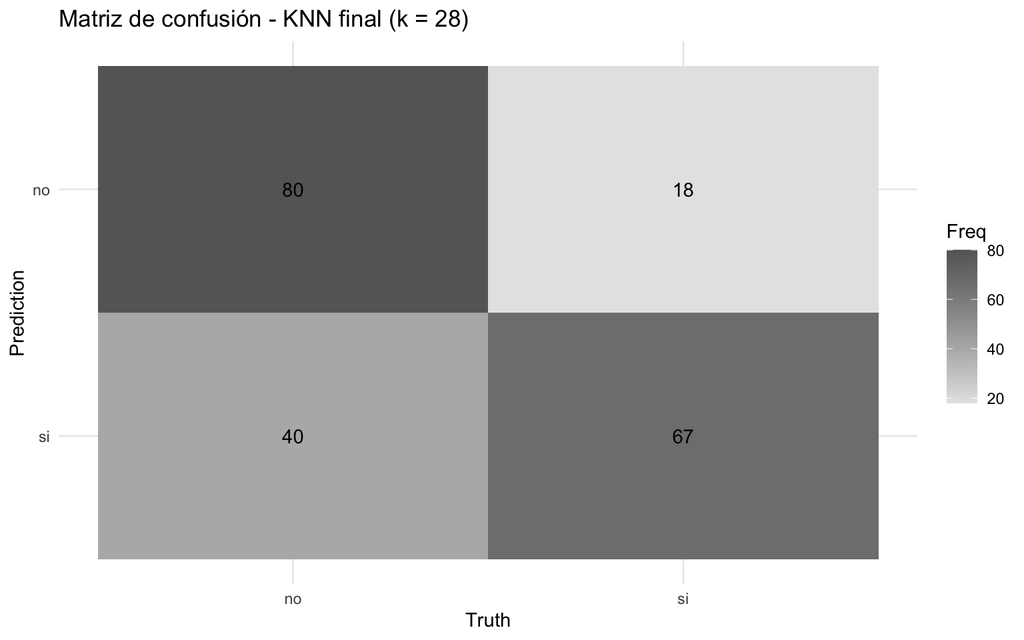

```r
# 7.3 Matriz de confusión final.
conf_mat(predicciones_finales,
         truth = potable,
         estimate = .pred_class) %>%
  autoplot(type = "heatmap") +
  labs(title = paste0("Matriz de confusión - KNN final (k = ",
                      mejor_k$neighbors, ")")) +
  theme_minimal()
```

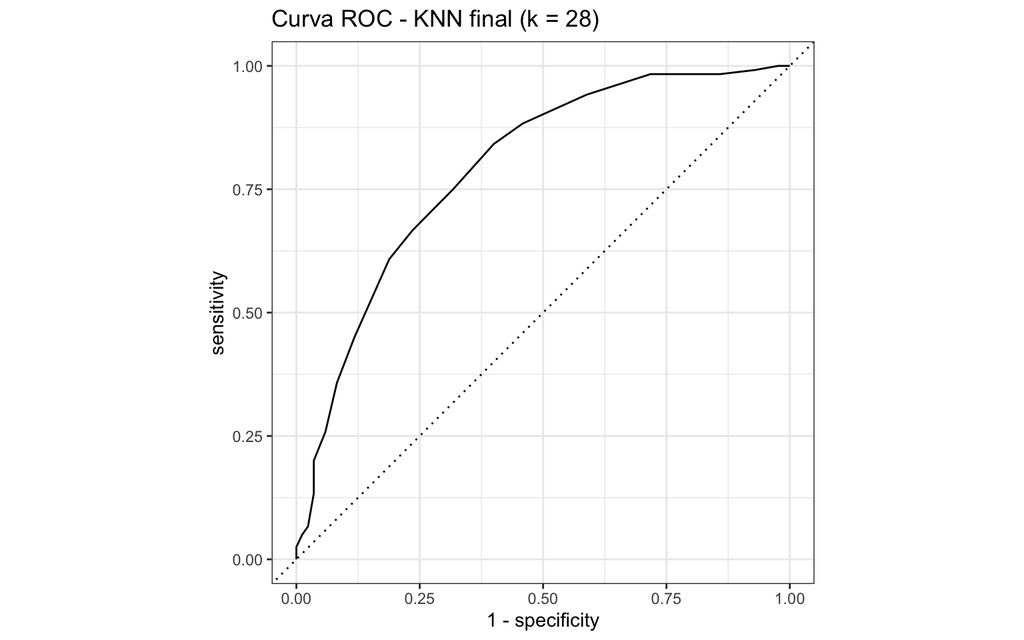

```r
# 7.4 Curva ROC y AUC final.
predicciones_finales %>%
  roc_curve(truth = potable, .pred_no) %>%
  autoplot() +
  labs(title = paste0("Curva ROC - KNN final (k = ", mejor_k$neighbors, ")"))
```

```r
roc_auc(predicciones_finales, truth = potable, .pred_no)
```

```
# A tibble: 1 × 3
  .metric .estimator .estimate
  <chr>   <chr>          <dbl>
1 roc_auc binary         0.793
```

Interpretación:

- El AUC final mide qué tan bien el modelo separa muestras potables de no potables (0.5 sería como tirar una moneda). En un problema real de calidad del agua nos interesaría especialmente la sensibilidad/especificidad según qué error sea más costoso: clasificar como potable algo que no lo es es peligroso, así que vigilaríamos de cerca esa tasa de falsos potables.
- Si el k óptimo de la CV es distinto del 9 inicial, confirmamos que vale la pena tunear en vez de adivinar. Y como normalizamos en la receta, el KNN pudo aprovechar todas las variables y no solo las de mayor magnitud.